# David Granjon

David Granjon

2021-10-05

# Aside

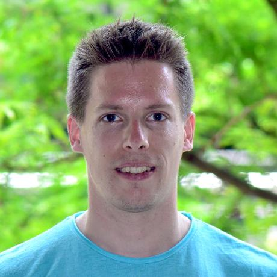

## Contact Info

- DivadNojnarg
- [RinteRface](https://rinterface.com)
- divadnojnarg

## References

Dr. Douglas Robinson  
Dr. Aurélie Edwards  
Pr. Olivier Bonny  
Dr. Laurent Pujo-Menjouet  
Dr. Diane de Zélicourt  
Pr. Vartan Kurtcuoglu

## Skills

- **Data Analysis:** R
- **Web development:** {Shiny}, JavaScript, React, HTML, CSS, Framework7, Bootstrap, webpack
- **Reporting:** {rmarkdown}, {pagedown}, {bookdown}, Latex
- **R-Workflow:** Git, CI/CD (github-actions, …), {renv}, {golem}, {devtools}, {profvis}, {usethis}, {testthat}, …

## Languages

- French (native)
- English (C1)

# Main

## David Granjon

### Currently: Senior Data Science Expert, Novartis AG

- Founder of [RinteRface](https://rinterface.com)
- R Shiny advocate

## Education

### PhD in Life Sciences

Thesis title: ”Modeling of Calcium Homeostasis in the Rat and its Perturbations”. Building of a mathematical model describing calcium homeostasis, including its analysis and simulation of pathologies. Advisors: Dr. Aurélie Edwards and Pr. Olivier Bonny.

Université Pierre et Marie Curie, Paris, Université de Lausanne, Switzerland

2013-2016

### Master’s Degree in Ecosiences, MIV

Main subjects: Mathematics, Theoretical Ecology and Programming.

Université Claude Bernard (UCBL), Lyon

2011-2013

### Licence (3 year degree) in Mathematics and Computer Sciences for the Living (MIV)

Main subjects: Mathematics, Ecology and Computer Sciences.

Université Claude Bernard (UCBL), Lyon

2010-2011

### Preparatory School for Engineers

Main subjects: Mathematics, Physics, Biology, Geology.

Lycée Claude Fauriel, Saint Etienne

2008-2010

## Professional Experience

### Principal Scientist and Consultant

Software development

Novartis AG (Basel)

06/19 - 06/21

Projects overview:

- Support Novartis associates to develop production ready Shiny apps for clinical activities.
- Deliver high quality workshops to promote best practices around Shiny apps.
- Maintain internal tools: R packages, databases, web servers, …
- Represent Novartis at international R conferences (R in Pharma).

### Post Doctoral Researcher

Software engineer

The Interface Group, University of Zurich (UZH)

06/17 - 06/19

Two main projects:

- Design user-friendly interfaces of Calcium and Phosphate Homeosta- sis, using the R-Shiny package, javascript and C. Management of linux web servers. Design new interactive tools dedicated to teaching courses.
- Develop a model linking the cardiac and renal functions, to better understand the interplay between chronic kidney disease as well as cardiac failure. Create virtual patient populations using Monte Carlo simulations.

[figure not shown]

Develop outstanding {shiny} apps for iOS, Android and desktop.

[figure not shown]

Bootstrap 4 shinydashboard using AdminLTE3.

[figure not shown]

### Post Doctoral Researcher

Improvements to the model developed during my doctoral thesis. Publication of a second article (see publications). Supervisors: Dr. Aurélie Edwards and Pr. Olivier Bonny.

CHUV, Lausanne university hospital, Switzerland.

01/17 - 03/17

### Internship in a Team of Theoretical Physiology

Improvements to the model developed during the previous internship. Supervisors: Dr. Moisés Santillan, Pr. Michael Mackey.

Centre for Applied Mathematics in Bioscience and Medicine (CAMBAM), Mc Gill University, Montreal, Canada.

07/13 - 08/13

### Internship in a Laboratory of Applied Mathematics

Project title: “Multiscale modeling of Zebrafish Somitogenesis”. Development of a model accounting for the intra-cellular oscillator in each cell during somitogenesis. Supervisors: Dr. Laurent Pujo-menjouet (UCBL), Pr. Michael Mackey (Mc Gill, Canada).

Institut National de Recherche en Informatique et Automatique (INRIA), Team Dracula, Lyon.

01/13 - 07/13

### Internship in a Laboratory of Applied Mathematics

Project title: “Mathematical modeling of somitogenesis, reaction- diffusion systems”. Analysis of two mathematical models: cell-cycle and clock/wavefront models. Supervisor: Dr. Laurent Pujo-Menjouet (UCBL).

Institut National de Recherche en Informatique et Automatique (INRIA), Team Dracula, Lyon.

03/12 - 07/12

### Internship in a Laboratory of Theoretical Ecology

Project title: “Ecotoxicology of Daphnia Magna”. Study of the impact of pollution on the growth of Daphnia Magna through mathematical models. Supervisors: Pr. Sandrine Charles (UCBL), Pr. Marie Laure Delignette Muller (Ecole Nationale Vétérinaire de Lyon).

Laboratoire de Biométrie et Biologie Evolutive (LBBE), Team Modélisation et Ecotoxycologie Prédictive (MEPS), Lyon.

06/11 - 08/11

## Publications

### An eLearning platform to teach calcium and phosphate homeostasis

Submitted to American Journal of Physiology-Advances in Physiology Education.

N/A

2019

D. Granjon, O. Bonny, F. Verrey, V. Kurtcuoglu and D. de Zelicourt.

### Coupling between Phosphate and Calcium Homeostasis: A Mathematical Model

American Journal of Physiology-Renal Physiology, 313(6): F1181-F1199. doi: 10.1152/ajprenal.00271.2017

N/A

2017

D. Granjon, O. Bonny, A. Edwards.

[figure not shown]

Extensions for shinydashboard.

[figure not shown]

[figure not shown]

Tools to develop Shiny extensions.

[figure not shown]

### A Model of Calcium Homeostasis in the Rat

American Journal of Physiology-Renal Physiology, 311 (5): F1047-F1062. doi: 10.1152/ajprenal.00230.2016

N/A

2016

D. Granjon, O. Bonny, A. Edwards.

## Books

### Outstanding User Interfaces with Shiny

This book provides the necessary knowledge to extend Shiny’s layout: https://unleash-shiny.rinterface.com.

CRC Press Forthcoming

2021

D. Granjon

## Conferences and Talks

### R in Pharma 2021

Workshop + talk

TBD

Oct-Nov 2021

### Beyond DataViz: How to Improve the UI/UX of Your Shiny Apps (Podcast)

Interview: `{deminR}` a R powered minesweeper: https://www.crowdcast.io/e/shiny-apps-UX-UI-design?__s=81h3pqtq7v4b70zpyfa1

Online

Wed., Sep. 29 @11am ET

### Rencontres R 2021

Workshop: `{shinyMobile}` Hands-on: https://github.com/RinteRface/rencontresR2021

Remote (Covid 2019)

07/09/2021

### Shiny Developers Series 2021

Podcast interview: “Outstanding User Interfaces with David Granjon: https://shinydevseries.com/post/episode-20-shinyui/.

Online

05/2021

### R in Pharma 2020

Workshop: Unleash Shiny: https://github.com/RinteRface/Unleash-Shiny

Remote (Covid 2019)

09/10/2020

### eRum 2020

Workshop: Advanced User Interfaces for Shiny Developers: https://github.com/Novartis/Advanced-User-Interfaces-for-Shiny-Developers, https://rinterface.com/shiny/talks/eRum2020/dg/#slide=1

Remote (Covid 2019)

May 2020

### satRdayNeuch 2020

Oral presentation: An introduction to shinyMobile: https://github.com/DivadNojnarg/satRdayNeuch2020.

Remote (Covid 2019)

14/03/2020

### Zurich R User Group

Oral presentation: “shinyMobile: Build Native Looking Shiny Apps: https://rinterface.com/shiny/talks/zurichR2020/index.html#slide=1.

Zurich

29/01/2020

### BaselR

Oral presentation: “Development of a web application to represent models of calcium and phosphate homeostasis using R.

Basel

05/12/2019

### Shiny Developers Series 2019

Podcast interview: “Production-ready UIs for Shiny: https://shinydevseries.com/post/episode-4-rinterface/.

Online

08/2019

### useR 2019

Poster presentation: “A Shiny Powered Virtual Patient: https://github.com/DivadNojnarg/userR2019.

Toulouse

09/07/19 - 12/07/19

### Zurich R User Group

Oral presentation: “RinteRface, Production-ready UIs for Shiny: https://rinterface.com/shiny/talks/zurichR2019/index.html#slide=1.

Zurich

27/05/19

### NCCR Kidney.CH Retreat 2019

Oral presentation: ”Web applications for physiology: bridge the gap between research and teaching”.

Murten, Switzerland

31/01/19 - 01/02/19

### NCCR Kidney.CH Summer School 2018

Poster first author: ”Web-based e-learning tools of Calcium and Phosphate Homeostasis”.

Zurich, Switzerland

09/09/18 - 12/09/18

### World Congress of Biomechanics 2018

Poster first author: ”Addressing biomedical diversity via eLearning, an example from a physiology curriculum”.

Dublin, Ireland

08/07/18 - 12/07/18

### NCCR Kidney.CH Retreat 2018

Poster first author: ”A web-based application of Calcium and Phosphate Homeostasis”.

Murten, Switzerland

01/02/18 - 02/02/18

### Bachelor–Themenworkshops 5. Semester HS 2017

Oral presentation: Computational Physiology.

Zurich University of the Arts, Switzerland

17/10/17

### Meeting of the Federation of Physiological Societies and the French Physiological Society

Poster presentation: ”Role of the rapidly exchangeable calcium pool in bone in calcium homeostasis”.

Centre de Recherche des Cordeliers, Paris

29/06/16 - 1/07/16

### Annual Franco-Swiss Meeting on Electrolytes Metabolism and Renal Physiology

Oral presentation: ”A model of Ca/Pi homeostasis in the Rat”.

Inselspital, Bern

23/03/16 - 24/03/16

### NCCR Kidney.CH Retreat 2016

Poster first author: ”Role of the bone rapidly exchangeable calcium pool in calcium homeostasis”.

Murten, Switzerland

25/02/16 - 27/02/16

### Société Francophone de Dialyse/Société de Néphrologie

Poster first author: ”Consequences of primary hyperparathyroidism on renal calcium excretion”.

Lyon, France

29/09/15 - 02/10/15

### Annual Franco-Swiss Meeting on Electrolytes Metabolism and Renal Physiology

Oral presentation: ”A Model of Calcium Homeostasis in the Rat”.

Centre de Recherche des Cordeliers, Paris

19/03/15 - 20/03/15

### Annual Franco-Swiss Meeting on Electrolytes Metabolism and Renal Physiology

Oral presentation: ”A Simplified Model of Plasma Calcium Regulation by PTH”.

CHUV, Lausanne

19/03/14 - 20/03/14

### Conference ” In honour of Michael Mackey’s 70th birthday

Oral presentation: ”Oscillatory dynamic during zebrafish somitogenesis”.

Lyon, France

3/06/13 - 6/06/13

## Awards

### 2021 RStudio Shiny Contest Judge

- Judge of the 2021 Shiny Contest.

N/A

Link: https://community.rstudio.com/t/commute-explorer-shiny-contest-submission/104651

2021

### 2020 RStudio Shiny Contest

- Runner-Up price: `{deminR}` a minesweeper for R.

N/A

Link: https://community.rstudio.com/t/deminr-a-minesweeper-for-r-2020-shiny-contest-submission/56356

2020

### 2019 RStudio Shiny Contest

- Runner-Up price: A Virtual Lab for Teaching Physiology.

N/A

Link: https://community.rstudio.com/t/shiny-contest-submission-a-virtual-lab-for-teaching-physiology/25348

2019

### NCCR Kidney.CH Retreat 2018

- Best Poster Award, 2nd price: A web-based application of Calcium and Phosphate Homeostasis.

N/A

N/A

This resume was made with the R package [**pagedown**](https://github.com/rstudio/pagedown).

Last updated on 2021-10-05.